# Credit Default Risk App

June 11, 2026

## The Problem

When a borrower fails to repay a loan, the lender absorbs the full loss. At scale, even a small improvement in identifying high-risk applicants translates to significant savings.

Most borrowers repay, but the rare defaulters are exactly who lenders need to identify. A model that flags everyone as low risk achieves over 90% accuracy while catching zero defaulters.

The real question is not **‘Is this model accurate?’** but rather **‘Does it catch the defaulters that matter, without rejecting too many creditworthy borrowers?’**

8.2% Default rate in dataset

91.8% Accuracy of a model that never flags anyone

0% Recall of that same model

## The Data & Model

**Dataset:** 291,643 real loan records from Home Credit, a consumer finance company. Originally released as a Kaggle competition.

**Features:** Derived from each loan’s payment history.

Fraction Late Mean Days Late Max Days Late Pay Ratio Fraction On Time Log Instalment Log Payment Loan Amount Annual Income

**Model:** Logistic regression - Interpretable, auditable, and consistent with real-world credit scoring practice where regulatory scrutiny favors explainable models.

0.605 AUC on held-out test set

70/30 Train / test split

0.10 Default decision threshold

## The Data in R

```r
# Load data and label default status
loan_data <- read.csv("loan_agg.csv")
loan_data$default <- factor(loan_data$TARGET,
                            labels = c("No Default", "Default"))

# Plot feature distribution by default status
ggplot(loan_data, aes(x = frac_late, fill = default)) +
  geom_density(alpha = 0.65) +
  coord_cartesian(
    xlim = c(quantile(loan_data$frac_late, 0.01),
             quantile(loan_data$frac_late, 0.99))
  ) +
  scale_fill_manual(
    values = c("No Default" = "#16a34a", "Default" = "#dc2626"),
    name = NULL
  ) +
  labs(x = "Fraction of Late Payments", y = "Density") +
  theme_minimal()
```

## Feature Distribution by Default Status

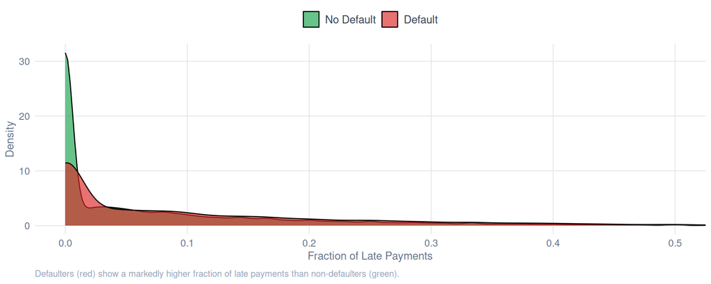

## The App

**Risk Assessment:** Enter an applicant’s details to get a default probability, risk verdict, and feature contribution chart.

| Profile | Frac Late | Days Late | On Time | Result |
| --- | --- | --- | --- | --- |
| Low Risk | 0.0 | -20 | 1.0 | ~6% |
| Borderline | 0.1 | 0 | 0.9 | ~7% |
| High Risk | 0.8 | 60 | 0.1 | ~20% |

**Decision Threshold Slider:** Drag it to see recall, precision, and the confusion matrix update live without re-scoring.

**ROC & Precision-Recall:** Live curves with a moveable dot at the current threshold.

**Data Explorer:** Feature distributions by default status confirming the model learned real signals.

Try It Now

**Live App**  
[arielrp.shinyapps.io/project](https://arielrp.shinyapps.io/project/)

**Source Code**  
github.com/arielrp01/credit_risk_app

## What’s Next

**Current limitations**

- AUC of 0.605 reflects a small feature subset. Full feature models reach ~0.78-0.80.
- No fairness audit performed. Fair lending law requires group-level disparity analysis before any real deployment.
- Static model with no retraining pipeline or drift monitoring.

**Next steps**

- Full feature set from all Home Credit data sources.
- Champion / challenger model comparison framework.
- Automated retraining and performance monitoring.
- Fairness audit across protected characteristics.